# Do my clusters make sense? Some statistical and biological clues to help…

DIGIT-BIO tutorial @ Ecully

Andrea Rau

andrea.rau@inrae.fr, https://andrea-rau.com

8 December 2022

#### Abstract

[Unsupervised classification (clustering)](https://digitbio-ia.github.io/sequences/concepts/s2_clustering) is used in many fields. But once a clustering result has been obtained, how can we evaluate its pertinence? In this work, we will work with several statistical and biological indices to reinforce our confidence (or not…) in a clustering result. We will use as an example the identification of co-expressed genes from transcriptomic data with finite mixture models.

# Contents

[figure not shown]

# 1 Getting started

We will first begin by installing the necessary packages for this tutorial:

```r
install.packages("BiocManager")
BiocManager::install(c("mclust", "clValid", "fpc", "ggplot2", "coseq",
                        "clusterProfiler", "org.Mm.eg.db"))
```

In some cases, installation of the *clusterProfiler* package may cause errors due to a dependence on the *ggtree* package (see [here](https://github.com/YuLab-SMU/ggtree/issues/544)). In this case, you can try using the following code to install the development version of *ggtree* before installing the remaining packages as described above.

```r
install.packages("remotes")
remotes::install_github('YuLab-SMU/ggtree')
```

Installation of all packages should take approximately ~15 min. Some participants have experienced difficulties installing the *clusterProfiler* and *org.Mm.eg.db* packages; note that these two packages are only used in the final section on external validation, and the remainder of the tutorial can be run without them.

# 2 Load packages and pre-formatted results

Next, we load all packages for the tutorial.

```r
library(clValid)          ## Package with several validation criteria
library(fpc)              ## Package with several validation criteria
library(mclust)           ## Package to fit Gaussian mixture models
library(coseq)            ## Co-expression analyses
library(ggplot2)          ## Plotting

library(clusterProfiler)  ## GO enrichment analysis
library(org.Mm.eg.db)     ## Mouse annotation
```

In this tutorial, we will make use of data from an RNA-seq experiment to study lineage of luminal cells in mouse mammary gland and changes in expression upon pregnancy and lactation ([Fu et al., 2015](https://pubmed.ncbi.nlm.nih.gov/25730472/)). The study included 2 cell types {basal stem-cell enriched cells, committed luminal cells} × 3 statuses {virgin, pregnant, lactating} × 2 biological replicates. Illumina HiSeq was used to produce 30 million 100bp SE reads. Pre-processing steps included alignment of reads to the mm10 genome with *Subread* and quantification of Entrez genes (RefSeq) using *featureCounts*. Further details about the study and these pre-processing steps can be found [here](https://bioconductor.org/packages/release/workflows/vignettes/RnaSeqGeneEdgeRQL/inst/doc/edgeRQL.html)).

Prior to this tutorial, raw counts from the study were downloaded and subjected to an initial analysis. Specifically, (1) genes with weak expression or ambiguous/missing IDs were filtered from the analysis, and *DESeq2* was used to perform library size normalization; (2) a differential analysis to identify genes with significantly differentially expression in at least one status group (results are saved in an RDS object called `Fu-GSE60450_dds.rds`); and (3) two co-expression analyses were performed on arcsine-transformed RNA-seq profiles using *coseq*:

1. **Gaussian mixture models** (GMM), using 20 independent runs over a range of cluster values from $K$=2, …, 20, with the best performer selected using the ICL criterion. Results are saved in an RDS object called `coexp_gmm.rds`.
2. **K-means** algorithm over a range of cluster values from $K$=2, …, 20, with the best performer selected using the slope heuristics criterion. Results are saved in an RDS object called `coexp_km.rds`.

We will examine a variety of cluster validation metrics on these two clustering results in the following tutorial. Note that code to regenerate these results can be found in the Appendix. For the purposes of this tutorial, all necessary pre-processed data files can be found on the associated [GitHub repo](https://github.com/andreamrau/2022_DIGIT-BIO_workshop).

To download the tutorial materials, you can navigate to the [GitHub repo](https://github.com/andreamrau/2022_DIGIT-BIO_workshop) and click on the green `Code` button to download a zipped file, as shown in the screenshot below.

[figure not shown]

After unzipping the file, the data files can be found in the `2022_DIGIT-BIO_workshop-main/data/` folder, and R/Rmarkdown scripts in the `2022_DIGIT-BIO_workshop-main/code/` folder. For interactively rerunning the scripts in this tutorial, you can open the `2022_DIGIT-BIO-atelier.R` file in R or RStudio. For the remainder, make sure that your current working directory is in your `2022_DIGIT-BIO_workshop-main/code/` folder by using the `getwd()` command to see your current working directory, and as needed `setwd(...)` to change it.

The files we will use in this tutorial are in `.rds` format, which is used to write a single `R` object to a file enabling it to be easily restored. We have used this format here since output from *coseq* is not in simple tabular format, as it includes meta-data such as posterior probabilities of cluster membership, model selection criteria values, input data, etc.

We then load these results below, and set the seed for the random number generator to ensure reproducible results:

```r
dds <- readRDS("../data/Fu-GSE60450_dds.rds")
coexp_gmm <- readRDS("../data/coexp_gmm.rds")
coexp_km <- readRDS("../data/coexp_km.rds")
set.seed(12345)
```

The data input into each of the clustering algorithms is a square table of transformed normalized profile values, with $n$=2317 genes in rows and $p$=12 samples in columns:

```r
tcounts(coexp_gmm)
```

```
## DataFrame with 2317 rows and 12 columns
##          MCL1.DG   MCL1.DH   MCL1.DI   MCL1.DJ   MCL1.DK   MCL1.DL   MCL1.LA
##        <numeric> <numeric> <numeric> <numeric> <numeric> <numeric> <numeric>
## 18777   0.239461  0.221938  0.300766  0.317286  0.329124  0.305199  0.272247
## 319263  0.244847  0.245767  0.256778  0.294193  0.347220  0.345469  0.221253
## 59014   0.326362  0.353412  0.381756  0.355761  0.253659  0.210895  0.276429
## 76982   0.231377  0.150390  0.225540  0.260290  0.600940  0.576757  0.135409
## 73824   0.308148  0.328722  0.352015  0.344656  0.261098  0.232466  0.333842
## ...          ...       ...       ...       ...       ...       ...       ...
## 66226   0.259032  0.220100  0.261278  0.299914  0.383095  0.359231  0.215737
## 56382   0.231686  0.216569  0.267984  0.256631  0.291948  0.316712  0.243017
## 17692   0.271243  0.264369  0.311450  0.321545  0.351680  0.326373  0.255581
## 15159   0.255802  0.266995  0.311141  0.299523  0.266632  0.269285  0.260827
## 170942  0.285755  0.287568  0.338189  0.334921  0.235653  0.183333  0.321357
##          MCL1.LB   MCL1.LC   MCL1.LD   MCL1.LE   MCL1.LF
##        <numeric> <numeric> <numeric> <numeric> <numeric>
## 18777   0.269836  0.273105  0.284918  0.333151  0.343410
## 319263  0.201813  0.241508  0.269573  0.386669  0.389685
## 59014   0.252173  0.291524  0.289945  0.232587  0.239584
## 76982   0.160801  0.191831  0.180442  0.208953  0.191471
## 73824   0.311040  0.263950  0.270174  0.237941  0.237048
## ...          ...       ...       ...       ...       ...
## 66226   0.232251  0.256887  0.268664  0.352202  0.348454
## 56382   0.249678  0.346813  0.350401  0.346370  0.352427
## 17692   0.261478  0.270789  0.279634  0.292503  0.292396
## 15159   0.258247  0.346767  0.347979  0.294239  0.318009
## 170942  0.333022  0.348386  0.322361  0.269154  0.201331
```

We have clustered rows of this data table to identify genes with similar expression patterns across the 12 experimental samples. Note that the clustering algorithms here do not make use of the sample labels (e.g., cell type, status). However, we will visualize the identified clusters with respect to these labels in the graphics in the following section.

# 3 Examine *coseq* clustering results

We first briefly examine the results for the two *coseq* clusterings. We start with the GMM results, and examine boxplots of the co-expression clusters. In the boxplots below, each facet represents an identified cluster, and boxplots for each of the 12 samples represent the respective normalized profile values for genes assigned to that cluster.

```r
coexp_gmm
```

```
## An object of class coseqResults
##  2317 features by 12 samples.
##  Models fit: K = 2 ... 20
##  Chosen clustering model: K = 10
```

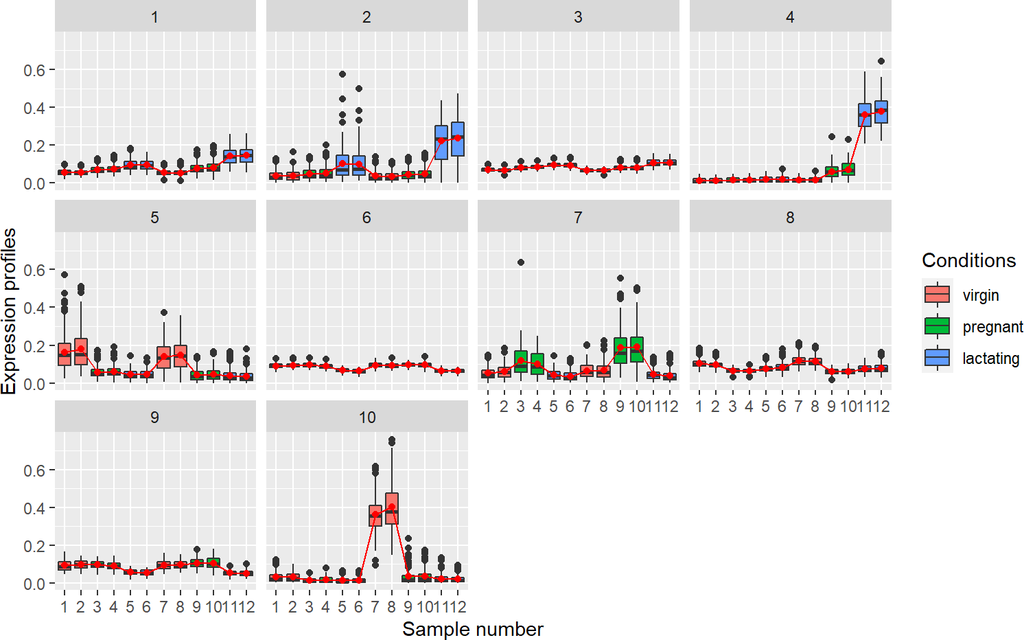

```r
plot(coexp_gmm, conds = dds$Status, graph = "boxplots")
```

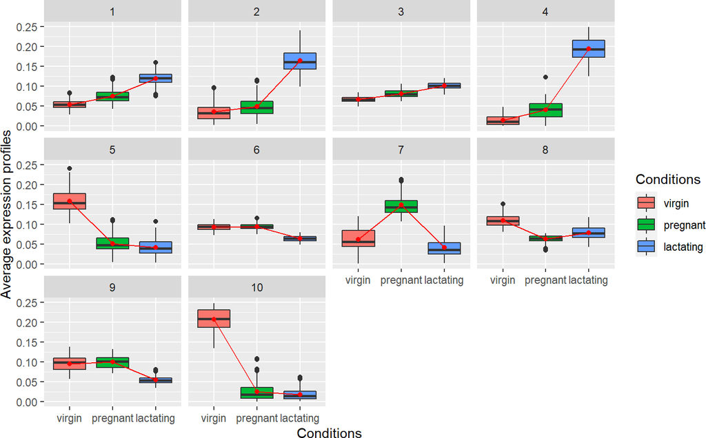

```r
plot(coexp_gmm, conds = dds$Status,
     collapse_reps = "average", graph = "boxplots")
```

Finally, we can consider the conditional probabilities of cluster membership for each cluster.

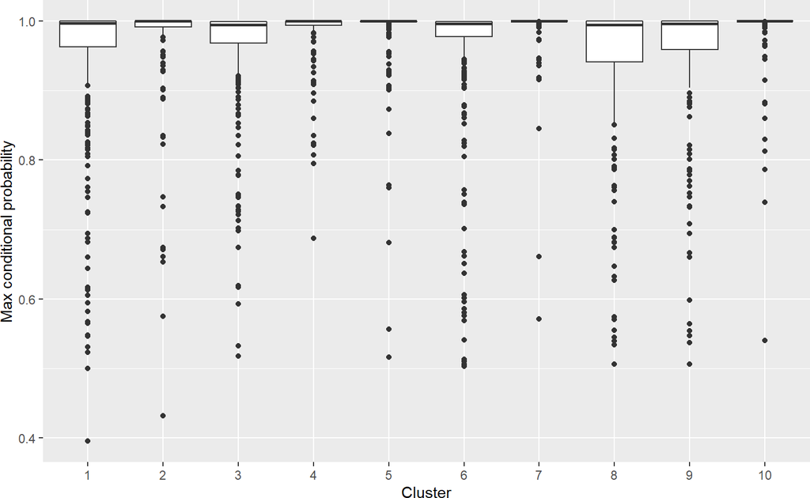

```r
plot(coexp_gmm, graphs = "probapost_boxplots")
```

Note that clusters that have very sharp, marked profiles (e.g. Cluster 10) tend to include genes with higher conditional probabilities. Genes assigned to clusters with less marked profiles (e.g., Cluster 1 or 3) likely have a more ambiguous clustering assignment, which is reflected by the larger range of values for the respective conditional probabilities.

We similarly examine results from the K-means algorithm. Note that clustering labels are arbitrary, so Cluster 1 from the GMM does not have any link to Cluster 1 from K-means. By exploiting the relationship between the K-means algorithm and a special case of the GMM (notably, spherical GMMs with estimation via the CEM algorithm), we can similarly calculate conditional probabilities of cluster assignment analagous to those seen above.

```r
coexp_km
```

```
## An object of class coseqResults
##  2317 features by 12 samples.
##  Models fit: K = 2 ... 20
##  Chosen clustering model: K = 9
```

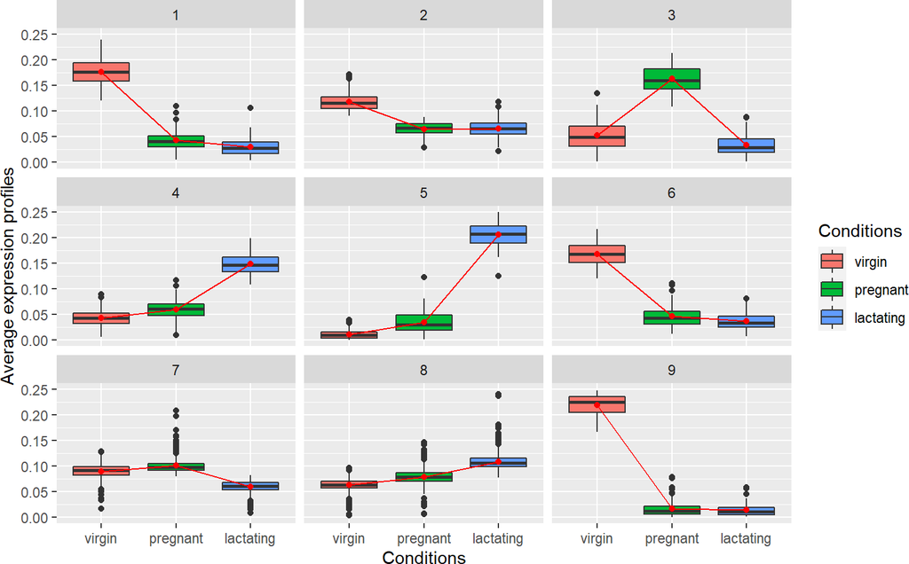

```r
plot(coexp_km, conds = dds$Status,
     collapse_reps = "average", graph = "boxplots")
```

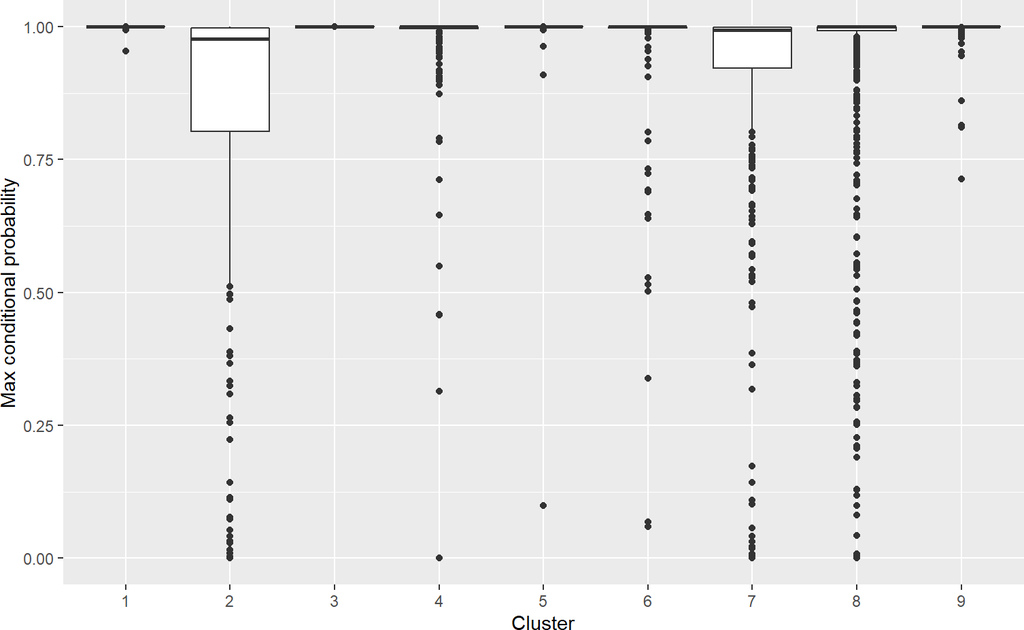

```r
plot(coexp_km, graphs = "probapost_boxplots")
```

# 4 Internal validation

Internal cluster validation seeks to evaluate the goodness of clustering structure using data alone. In other words, we aim to evaluate the extent to which genes with a given cluster are similar, as well as the extent to which genes in different clusters are distinct. Measures of internal validation are typically defined using measures of (1) *compactness*, (2) *connectivity*, and/or (3) *separation*.

In this section, we will examine two criteria for internal cluster validation: the Silhouette width, and the Dunn index. For each of these, note that we make use of the transformed normalized counts produced internally for clustering by *coseq*, accessible using `tcounts(coexp_gmm)`, rather than the raw counts.

## 4.1 Silhouette width

The silhouette statistic is a measure of how closely data within a cluster is matched (compactness) and how loosely it is matched to neighboring clusters (separation). It is defined as follows:

$$a(i) = \frac{1}{\vert C_I \vert - 1}\sum_{j\in C_I, i \ne j} d(i,j) \text{ and } b(i) = \min_{J\ne I} \frac{1}{\vert C_J \vert}\sum_{j\in C_J} d(i,j) \textsf{, for } i \in C_I$$

$$s(i) = \frac{b(i)-a(i)}{\max \lbrace a(i), b(i) \rbrace}$$

The silhouette width can take values from -1 to 1. **Observations (genes) with a large silhouette width are typically considered to be well clustered**, while values close to 0 may indicate that an observation lies between two clusters. Observations with a negative $s_i$ may be assigned to an incorrect cluster.

The results for the GMM clustering are shown below. In the graphic, genes are plotted on the x-axis, and $s_i$ values on the y-axis, with different colors representing each cluster. Which clusters appear to be the best formed? Which are the fuzziest?

```r
sil_gmm <- cluster::silhouette(clusters(coexp_gmm), dist(tcounts(coexp_gmm)))
summary(sil_gmm)
```

```
## Silhouette of 2317 units in 10 clusters from silhouette.default(x = clusters(coexp_gmm), dist = dist(tcounts(coexp_gmm))) :
##  Cluster sizes and average silhouette widths:
##         370         139         415         151         256         369
## -0.09239537 -0.24854753  0.37127096  0.37640803 -0.10942006  0.31614633
##          91         218         187         121
## -0.15961943  0.05520831 -0.14555748  0.40571603
## Individual silhouette widths:
##    Min. 1st Qu.  Median    Mean 3rd Qu.    Max.
## -0.6093 -0.1372  0.1490  0.1080  0.3572  0.6116
```

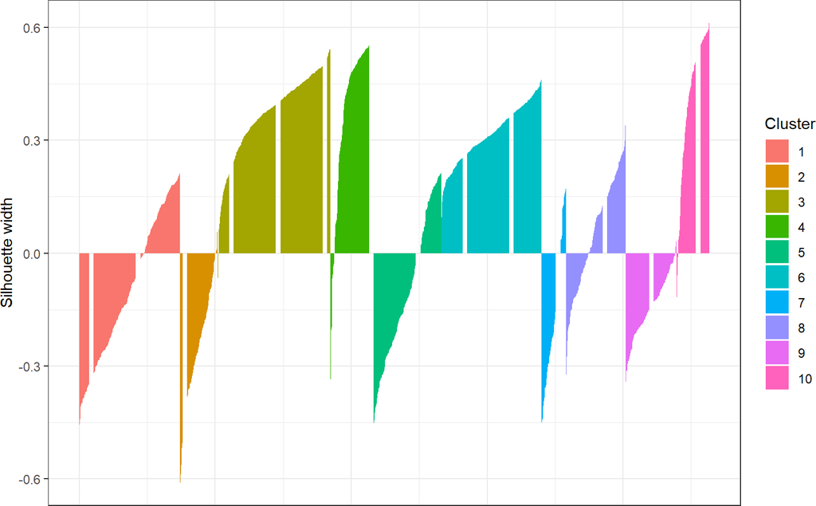

```r
sil_df_gmm <- data.frame(as(sil_gmm, "matrix"))
sil_df_gmm$Cluster <- factor(sil_df_gmm$cluster)
sil_df_gmm <- sil_df_gmm[order(sil_df_gmm$cluster, sil_df_gmm$sil_width),]
ggplot(sil_df_gmm) +
  geom_col(aes(x=1:nrow(sil_df_gmm), y=sil_width, fill = Cluster)) +
  ylab("Silhouette width") +
  theme_bw() +
  theme(axis.title.x=element_blank(),
        axis.text.x=element_blank(),
        axis.ticks.x=element_blank())
```

We now examine the same results for the K-means results. What do you notice?

One thing to keep in mind is that the silhouette statistic is defined above using a distance $d(i,j)$, typically the Euclidean distance. Here, it is perhaps unsuprising that the K-means algorithm has “better” performance than the GMM, as it explicity forms clusters based on respectively minimizing and maximizing intra- and inter-cluster Euclidean distances.

```r
sil_km <- cluster::silhouette(clusters(coexp_km), dist(tcounts(coexp_km)))
summary(sil_km)
```

```
## Silhouette of 2317 units in 9 clusters from silhouette.default(x = clusters(coexp_km), dist = dist(tcounts(coexp_km))) :
##  Cluster sizes and average silhouette widths:
##        86       330        38       211       140       113       560       753
## 0.2732263 0.1217020 0.1648148 0.2339109 0.4025636 0.1381657 0.2905217 0.3330585
##        86
## 0.3382664
## Individual silhouette widths:
##    Min. 1st Qu.  Median    Mean 3rd Qu.    Max.
## -0.2125  0.1655  0.2912  0.2736  0.3966  0.5958
```

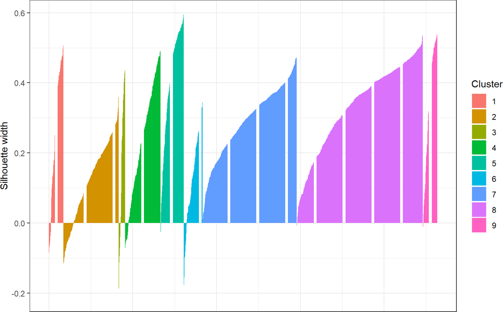

```r
sil_df_km <- data.frame(as(sil_km, "matrix"))
sil_df_km$Cluster <- factor(sil_df_km$cluster)
sil_df_km <- sil_df_km[order(sil_df_km$cluster, sil_df_km$sil_width),]
ggplot(sil_df_km) +
  geom_col(aes(x=1:nrow(sil_df_km), y=sil_width, fill = Cluster)) +
  ylab("Silhouette width") +
  theme_bw() +
  theme(axis.title.x=element_blank(),
        axis.text.x=element_blank(),
        axis.ticks.x=element_blank())
```

## 4.2 Dunn index

We next consider the Dunn index, which corresponds to the ratio of the smallest distance between clusters and the largest intra-cluster distance (diameter). It is defined as follows:

$$\textsf{DI} = \frac{\min\limits_{C_I, C_J, I\ne J} \left( \min\limits_{i\in C_I, j \in C_J} d(i,j)\right)}{\max\limits_{C_M} \textsf{diam}(C_M)}$$
where $\textsf{diam}(C_M)$ is the maximum distance among $i \in C_M$, $0 < \textsf{DI}$.

**Higher values of DI represent better results**. Once again, the Euclidean distance is used below.

What do you notice?

```r
coexp_gmm_dunn <- cluster.stats(d = dist(tcounts(coexp_gmm)),
                             clusters(coexp_gmm))$dunn
coexp_km_dunn <- cluster.stats(d = dist(tcounts(coexp_km)),
                                clusters(coexp_km))$dunn
cat("DI (GMM) =", coexp_gmm_dunn, "\nDI (K-means) =", coexp_km_dunn, "\n")
```

```
## DI (GMM) = 0.02072885
## DI (K-means) = 0.02722065
```

# 5 Stability validation

As in the previous section, we make use of the transformed normalized counts produced internally for clustering by *coseq* via `tcounts(coexp_gmm)` rather than the raw counts. Both methods considered here rerun the clustering algorithm for subsets of the data; to this end, we make use of interface functions provied directly by each package: respectively, `clMethods = c("model", kmeans")` and `clustermethod = c(noisemclustCB, kmeansCBI)`.

## 5.1 *clValid*: removing each column one by one

To evaluate the stability of a clustering result, *clValid* proposes the successive removal of each column in the input data. For each data subset, the clustering analysis is rerun, and several metrics are calculated (with averages taken over all deleted columns):

- **Average proportion of non-overlap** (APN): measures the average proportion of observations not placed in the same cluster under both cases
- **Average distance** (AD): measures the average distance between observations placed in the same cluster under both cases
- **Average distance between means** (ADM): measures the average distance between cluster centers for observations placed in the same cluster under both cases
- **Figure of merit** (FOM): measures the average intra-cluster variance of the deleted column, where the clustering is based on the remaining (undeleted) columns.

Note that the APN, AD, and ADM are all based on the cross-classification table of the original clustering with the clustering based on the removal of one column. **For all criteria, smaller values are better.**

We first examine results for the GMM.

```r
coexp_gmm_stability <-
  clValid(as.matrix(tcounts(coexp_gmm)),
          nClust=max(clusters(coexp_gmm)), maxitems = nrow(coexp_gmm),
          clMethods = "model",
          validation = "stability")
summary(coexp_gmm_stability)
```

```
##
## Clustering Methods:
##  model
##
## Cluster sizes:
##  10
##
## Validation Measures:
##                10
##
## model APN  0.3541
##       AD   0.2551
##       ADM  0.0925
##       FOM  0.0580
##
## Optimal Scores:
##
##     Score  Method Clusters
## APN 0.3541 model  10
## AD  0.2551 model  10
## ADM 0.0925 model  10
## FOM 0.0580 model  10
```

We now examine results for the K-means algorithm.

```r
coexp_km_stability <-
  clValid(as.matrix(tcounts(coexp_km)),
          nClust=max(clusters(coexp_km)), maxitems = nrow(coexp_km),
          clMethods = "kmeans",
          validation = "stability")
summary(coexp_km_stability)
```

```
##
## Clustering Methods:
##  kmeans
##
## Cluster sizes:
##  9
##
## Validation Measures:
##                  9
##
## kmeans APN  0.1232
##        AD   0.2244
##        ADM  0.0380
##        FOM  0.0540
##
## Optimal Scores:
##
##     Score  Method Clusters
## APN 0.1232 kmeans 9
## AD  0.2244 kmeans 9
## ADM 0.0380 kmeans 9
## FOM 0.0540 kmeans 9
```

What do you notice?

## 5.2 *fpc*: bootstrap resampling of data

To evaluate the stability of a clustering result, *fpc* proposes the use of bootstrap resampling of the data. For each of the $B$ resampled data subsets, the clustering analysis is rerun and the Jaccard similarity index is calculated with respect to the original clusters. The average clusterwise Jaccard bootstrap value can provide an indication of the stability of specific clusters.

Generally, a valid, stable cluster should yield a mean Jaccard similarity value of 0.75 or more, while values between 0.6 and 0.75 may be considered as indicative of patterns in the data. Values < 0.6 indicate clusters with low confidence. Jaccard similarity indices < 0.5 are considered to represent a “dissolved” cluster; “recovered” clusters represent those with high Jaccard similarity indices (although the specific threshold used in the package is not indicated in the documentation).

In general, **good performance is indicated by high average clusterwise Jaccard bootstrap values, few dissolved clusters, and a number of recovered clusters as close to the number of bootstrap resamples $B$ as possible**.

We first examine the GMM results. Notice that we use a small number of bootstrap resamples here ($B$=20) to limit the computational time needed for this tutorial – **in practice, a larger number (e.g., $B$=100) should be used.**

```r
coexp_gmm_boot <-
  clusterboot(tcounts(coexp_gmm), B=20, k=max(clusters(coexp_gmm)),
              seed=20,bootmethod="boot",
              clustermethod=noisemclustCBI)
```

```
## boot 1
## boot 2
## boot 3
## boot 4
## boot 5
## boot 6
## boot 7
## boot 8
## boot 9
## boot 10
## boot 11
## boot 12
## boot 13
## boot 14
## boot 15
## boot 16
## boot 17
## boot 18
## boot 19
## boot 20
```

```r
print(coexp_gmm_boot)
```

```
## * Cluster stability assessment *
## Cluster method:  mclustBIC
## Full clustering results are given as parameter result
## of the clusterboot object, which also provides further statistics
## of the resampling results.
## Number of resampling runs:  20
##
## Number of clusters found in data:  10
##
##  Clusterwise Jaccard bootstrap (omitting multiple points) mean:
##  [1] 0.7896421 0.7699174 0.4647800 0.5875188 0.4117590 0.4432056 0.5203994
##  [8] 0.4732208 0.8337395 0.8256728
## dissolved:
##  [1]  0  0 11  6 12 13 10 13  0  0
## recovered:
##  [1] 14 11  1  3  0  1  3  0 16 16
```

We now examine the K-means results.

```r
coexp_km_boot <-
  clusterboot(tcounts(coexp_km), B=20, k=max(clusters(coexp_km)),
              seed=20,bootmethod="boot",
              clustermethod=kmeansCBI)
```

```
## boot 1
## boot 2
## boot 3
## boot 4
## boot 5
## boot 6
## boot 7
## boot 8
## boot 9
## boot 10
## boot 11
## boot 12
## boot 13
## boot 14
## boot 15
## boot 16
## boot 17
## boot 18
## boot 19
## boot 20
```

```r
print(coexp_km_boot)
```

```
## * Cluster stability assessment *
## Cluster method:  kmeans
## Full clustering results are given as parameter result
## of the clusterboot object, which also provides further statistics
## of the resampling results.
## Number of resampling runs:  20
##
## Number of clusters found in data:  9
##
##  Clusterwise Jaccard bootstrap (omitting multiple points) mean:
## [1] 0.8954206 0.8708561 0.8957294 0.9025149 0.7275505 0.4427935 0.7565571
## [8] 0.7340440 0.8310351
## dissolved:
## [1]  0  0  0  0  3 12  4  7  0
## recovered:
## [1] 17 15 19 18 12  7 15 11 15
```

What do you notice?

# 6 External validation

External validation metrics seek to evaluate the ability of a clustering algorithm to produce biologically meaningful clusters. For co-expression analyses, this meaningfulness is typically evaluated with respect to:

- Gene ontology (GO) term annotations
- A priori functional categorizations of genes
- Pathway membership
- Lists of genes of interest
- … or other relevant biological information

For this section, we thus generally assume that we have a set of $F$ known and potentially overlapping biological classes.

## 6.1 Adjusted Rand Index

The adjusted Rand index (ARI) is used to compare two clustering partitions, or to compare a clustering result to known labels. The ARI corresponds to a corrected-for-chance version of the Rand index, and values close to 1 indicate high agreement between the two sets of labels. The ARI can be used here to compare the clusterings obtained between the GMM and K-means:

```r
adjustedRandIndex(clusters(coexp_gmm), clusters(coexp_km))
```

```
## [1] 0.4623815
```

As an illustration, we can also calculate the ARI between chromosomes and clustering labels. Here, the biological interest is perhaps limited, but confirms that there is no association between GMM or K-means clusters and chromosomes.

```r
chr_info <- rowData(dds)[match(rownames(coexp_gmm),
                               rownames(rowData(dds))),"TXCHROM"]
table(chr_info)
```

```
## chr_info
##  chr1 chr10 chr11 chr12 chr13 chr14 chr15 chr16 chr17 chr18 chr19  chr2  chr3
##   130   109   209    74    84    72   102    79   135    58    81   184   122
##  chr4  chr5  chr6  chr7  chr8  chr9  chrX  chrY
##   135   150   111   169   119   125    68     1
```

```r
adjustedRandIndex(clusters(coexp_gmm), chr_info)
```

```
## [1] 0.002042875
```

```r
adjustedRandIndex(clusters(coexp_km), chr_info)
```

```
## [1] -0.0004378452
```

## 6.2 BHI and BSI

The *clValid* package proposes two external validation measures:

- **Biological homogeneity index** (BHI): measures the average proportion of gene pairs that are clustered together which have matching biological functional classes
- **Biological stability index** (BSI): inspects the consistency of clustering for genes with similar biological functionality (similar to other stability measures, where each sample is removed one at a time)

For each of these measures, we can use the Mouse annotation package *org.Mm.eg.db* from [Bioconductor](https://www.bioconductor.org/) to specify the Gene Ontology (GO) terms corresponding to the functional classes of genes. We focus in particular on the Biological Process (BP) ontology for this analysis.

For each of these criteria, **values closer to 1 indicate better performance**.

```r
coexp_gmm_bio <- clValid(as.matrix(tcounts(coexp_gmm)),
                        nClust = max(clusters(coexp_gmm)),
                        maxitems = nrow(coexp_gmm),
                        clMethods = c("model"),
                        validation = c("biological"),
                        annotation = "org.Mm.eg.db",
                        GOcategory = "BP")
```

```r
coexp_km_bio <- clValid(as.matrix(tcounts(coexp_km)),
                       nClust = max(clusters(coexp_km)),
                       maxitems = nrow(coexp_km),
                       clMethods = c("kmeans"),
                       validation = c("biological"),
                       annotation = "org.Mm.eg.db",
                       GOcategory = "BP")
```

```r
optimalScores(coexp_gmm_bio)
```

```
##          Score Method Clusters
## BHI 0.09690346  model       10
## BSI 0.13962494  model       10
```

```r
optimalScores(coexp_km_bio)
```

```
##          Score Method Clusters
## BHI 0.09484575 kmeans        9
## BSI 0.27825764 kmeans        9
```

What do you observe?

## 6.3 GO enrichment analysis

The final assessment criterion we will examine concerns the *characterization*, rather than the *validation*, of clusters. Specifically, we seek to identify which biological processes (e.g., GO terms) appear to be enriched in clusters of interest. This is done using an enrichment analysis, where we seek to identify whether the proportion of genes annotated for a given GO term in our cluster of interest is significantly different than the proportion of annotated genes overall (i.e., the so-called *gene universe*). In this example, we take as a gene universe the genes considered for the clustering analysis; it is debatable whether it should instead be defined as the set of expressed genes that were included in the initial differential analysis.

Although more sophisticated tests do exist, most enrichment analyses are based on a Fisher’s exact test. We make use of the *clusterProfiler* package, which interfaces nicely with visualization functions and Bioconductor annotation packages. As an example, we focus on cluster 10 from the GMM clustering result.

```r
cl <- coexp_gmm
kchoose <- 10
ego <- enrichGO(gene = rownames(cl)[which(clusters(cl) == kchoose)],
                universe = rownames(cl),
                OrgDb = org.Mm.eg.db,
                ont = "BP")
```

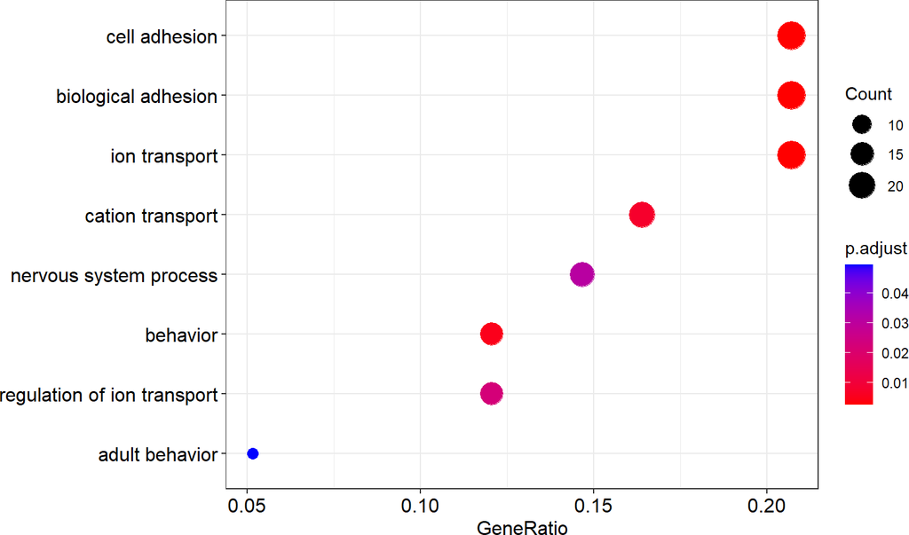

```r
dotplot(ego, showCategory=15)
```

```r
head(summary(ego))
```

```
##                    ID                 Description GeneRatio  BgRatio
## GO:0007155 GO:0007155               cell adhesion    24/116 169/2228
## GO:0022610 GO:0022610         biological adhesion    24/116 172/2228
## GO:0006811 GO:0006811               ion transport    24/116 175/2228
## GO:0007610 GO:0007610                    behavior    14/116  73/2228
## GO:0006812 GO:0006812            cation transport    19/116 131/2228
## GO:0043269 GO:0043269 regulation of ion transport    14/116  86/2228
##                  pvalue    p.adjust      qvalue
## GO:0007155 2.673996e-06 0.002456754 0.002238995
## GO:0022610 3.698692e-06 0.002456754 0.002238995
## GO:0006811 5.072445e-06 0.002456754 0.002238995
## GO:0007610 1.348245e-05 0.004897501 0.004463402
## GO:0006812 2.567262e-05 0.007460462 0.006799190
## GO:0043269 9.283778e-05 0.022482217 0.020489462
##                                                                                                                                                             geneID
## GO:0007155     17863/11846/18208/11687/320772/18191/16854/268780/22422/12837/13508/18190/16181/545428/22403/110135/71790/71421/27205/19242/66797/56753/15930/71908
## GO:0022610     17863/11846/18208/11687/320772/18191/16854/268780/22422/12837/13508/18190/16181/545428/22403/110135/71790/71421/27205/19242/66797/56753/15930/71908
## GO:0006811 17863/11846/20856/11443/76408/238076/30955/16854/71145/105727/209195/667742/16181/241877/16508/110935/108096/16514/20927/269994/55925/67801/22068/19417
## GO:0007610                                                                  11443/19049/18191/218476/13508/18190/16181/16508/19242/66797/110935/259277/20927/15930
## GO:0006812                                 17863/11846/20856/11443/238076/30955/16854/71145/105727/667742/241877/16508/110935/16514/20927/269994/55925/22068/19417
## GO:0043269                                                                  11846/20856/238076/30955/16854/209195/16181/16508/16514/20927/269994/55925/22068/19417
##            Count
## GO:0007155    24
## GO:0022610    24
## GO:0006811    24
## GO:0007610    14
## GO:0006812    19
## GO:0043269    14
```

# 7 Going further …

There are many ways of performing clustering analysis and validating the resulting clusters. For many of the measures of cluster validity presented in this tutorial, values are to be interpreted relatively to compare between results (algoriths, numbers of clusters, etc), and an objective threshold establishing a “good” versus a “bad” clustering result (or individual cluster) may not exist.

To go further, you could try the following:

- Generate random data (or several random datasets), and evaluate the various validation criterion presented in this tutorial. How do the values compare to those of the observed data?
- Consider one of the many other clustering algorithms available, and compare to the results shown for K-means and GMM: hierarchical clustering , self-organizing maps (SOM), DIvisive ANAlysis (DIANA), partitioning around mediods (PAM), just to name a few…
- Identify consensus clusters when varying the number of clusters or across different clustering algorithms, for example with *ConsensusClusterPlus*.

# 8 Appendix: Creating initial data files

The differential and co-expression analysis results that were loaded in the first step of this tutorial were generated with the following code:

```r
library(RnaSeqGeneEdgeRQL)
library(DESeq2)
library(Mus.musculus)


## Read in targets file --------------------------------------------------------
targetsFile <-
  system.file("extdata", "targets.txt", package="RnaSeqGeneEdgeRQL")
targets <- read.delim(targetsFile, stringsAsFactors=FALSE)
targets$ID <- rownames(targets)
targets$Status <- factor(targets$Status,
                         levels = c("virgin", "pregnant", "lactating"))
targets


## Download gene-wise read counts from NCBI ------------------------------------
FileURL <- paste(
     "http://www.ncbi.nlm.nih.gov/geo/download/?acc=GSE60450",
     "format=file",
     "file=GSE60450_Lactation-GenewiseCounts.txt.gz",
     sep="&")
download.file(FileURL, "GSE60450_Lactation-GenewiseCounts.txt.gz")

GenewiseCounts <-
  read.delim("GSE60450_Lactation-GenewiseCounts.txt.gz",
             row.names="EntrezGeneID")
colnames(GenewiseCounts) <- substring(colnames(GenewiseCounts),1,7)
counts <- GenewiseCounts[,-1] ## First column is gene lengths
counts <- counts[-which(rowSums(counts) == 0),]

dim(counts)
head(counts)


## Gene names ------------------------------------------------------------------
geneid <- rownames(counts)
genes <- select(Mus.musculus, keys=geneid, columns=c("SYMBOL", "TXCHROM"),
                keytype="ENTREZID")
## Remove multi-mapped genes
genes <- genes[!duplicated(genes$ENTREZID),]
all.equal(unlist(genes$ENTREZID), rownames(counts))
dim(genes)
head(genes)


## Differential analysis to screen DE genes ------------------------------------
dds <- DESeqDataSetFromMatrix(counts, targets, design = ~ Status)
rowData(dds) <- genes
## Remove weakly expressed genes
keep <- rowSums(counts(dds) >= 20) >= 2
dds <- dds[keep,]
## Remove genes missing a symbol or chromosome
keep2 <- which(rowSums(is.na(rowData(dds))) == 0)
dds <- dds[keep2,]
dds <- DESeq(dds, test="LRT", reduced = ~1)
res <- results(dds, alpha = 0.05)
hist(res$pvalue, breaks = 50, main = "Raw p-values")


## Run coseq for co-expression analysis ----------------------------------------
coexp_gmm_all <- vector("list", length = 20)
for(i in 1:20) {
    coexp_gmm_all[[i]] <- coseq(dds, alpha = 0.05, K = 2:20,
                                model = "Normal", transformation = "arcsin")
}
ICL_all <- unlist(lapply(coexp_gmm_all, function(x) min(ICL(x))))
best_gmm_result <- which.min(ICL_all)
coexp_gmm <- coexp_gmm_all[[best_gmm_result]]

coexp_km <- coseq(dds, alpha = 0.05, K = 2:20, seed=12345,
                  model = "kmeans", transformation = "arcsin")

## Save DE and coseq results ---------------------------------------------------
saveRDS(dds, file = "Fu-GSE60450_dds.rds")
saveRDS(coexp_gmm, file = "coexp_gmm.rds")
saveRDS(coexp_km, file = "coexp_km.rds")
```

These steps were hugely inspired by the workflows found in the [RnaSeqGeneEdgeRQL vignette](https://bioconductor.org/packages/release/workflows/vignettes/RnaSeqGeneEdgeRQL/inst/doc/edgeRQL.html) and in a [F1000 Software Tool article](https://f1000research.com/articles/5-1408).